# SGH Data Analyst test

### Construction of decision tree model

The decision tree will attempt to classify diabetics based on the 5 chosen variables. To determine the variable used to split the dataset, the Gini impurity, (a value which determines how good the split is, based on the amount of unique classes left in the child nodes) is calculated for each predictor variable. The lower the Gini impurity, the better the split. The data is then divided into the child nodes, and for each child node, the Gini impurity is calculated using the remaining variables, a variable is used for a split, and the dataset is divided until the terminal nodes have only one class remaining.

10-fold cross validation was used to optimize the complexity of the tree (cp). Smaller cp values give more complex trees with more branches. But could lead to overfitting. The cp value with the highest accuracy score was used to train the final model.

```r
# Optimize cp value for decision trees.
control <- trainControl(method = "repeatedcv",
                        number = 10,
                        search = "grid")

decision_tree <- train(diabetes ~ ., data = train_df, 'rpart', trControl = control)

decision_tree
```

```
## CART
##
## 3754 samples
##    5 predictor
##    2 classes: '0', '1'
##
## No pre-processing
## Resampling: Cross-Validated (10 fold, repeated 1 times)
## Summary of sample sizes: 3379, 3378, 3378, 3379, 3378, 3379, ...
## Resampling results across tuning parameters:
##
##   cp           Accuracy   Kappa
##   0.003159003  0.9227461  0.5773694
##   0.003685504  0.9251454  0.5966206
##   0.375921376  0.9062291  0.2967218
##
## Accuracy was used to select the optimal model using the largest value.
## The final value used for the model was cp = 0.003685504.
```

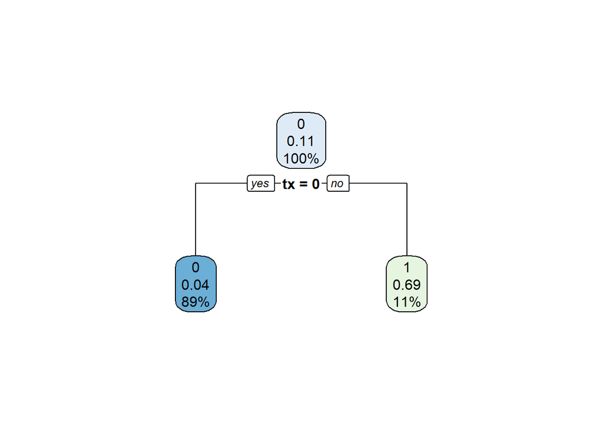

```r
# Visualize the optimized model.
rpart.plot(decision_tree$finalModel)
```

```r
# Use the model to predict diabetic labels.
decision_tree_predictions <- predict(decision_tree, newdata = test_df)

tree_results <- confusionMatrix(decision_tree_predictions,
                                test_df$diabetes,
                                positive = '1')
```

The initial tree only has the root node and one split. This means that it thinks the best variable for classifying the data is the tx variable. The current interpretation of this tree is: if tx = 0 is true, it means the patient is non-diabetic, while if tx = 0 is false, the patient is diabetic.

The tree is likely being pruned early to prevent overfitting (The model performs well on training data but performs poorly on test data). This happens when a more complicated tree is built, and only a small proportion of the dataset falls within one of the leaf nodes. This gives us poor confidence in the model when doing classification on future datasets, and so the model has decided to use tx as the first and only split to determine if someone was diabetic.

It is possible to force the model to use more variables as splits by adjusting the cp (complexity) argument of rpart(), so this was performed as well.

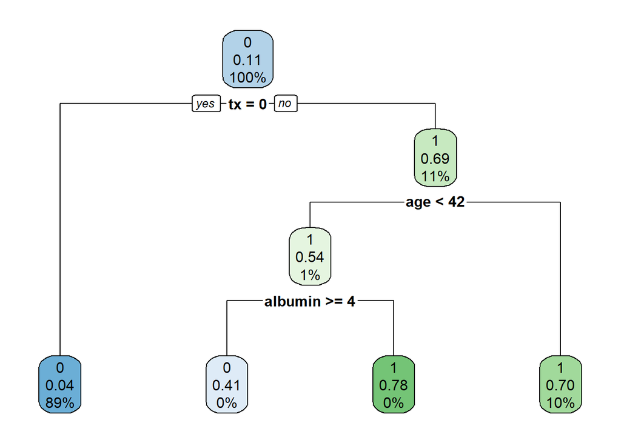

```r
# Create and visualize a more complex tree. Use rpart to manually specify cp value
decision_tree_low_cp <- rpart(diabetes ~ ., data = train_df, cp = 0.0036)

rpart.plot(decision_tree_low_cp)
```

### Construction of random forest model

The random forest model utilizes many decision trees and bootstrapping. Bootstrapping creates new datasets by selecting random rows from the original dataset, with replacement. For each bootstrapped dataset, a decision tree is constructed. The decision tree’s splits are made using the same methodology as the decision tree model, but only a limited subset of all variables are considered at each split. Multiple trees are constructed by repeating the process, and the test data set is passed through each tree before consensus voting occurs. The number of trees voting for each classification (diabetic / non-diabetic) are summed up and the classification with the higher vote count is used.

A 10-fold cross-validation to optimize the number of variables randomly selected at each split (mtry). For every partition of the data, several values of mtry are tested, and the accuracy is logged. It continues doing this for all partition and averages out the accuracy values for each mtry value before picking the mtry that yields the highest accuracy. The final model is then trained using this mtry value.

```r
# Create random forest model.
rf <- train(diabetes ~ .,
            data = train_df,
            method = 'rf',
            trControl = control)

rf
```

```
## Random Forest
##
## 3754 samples
##    5 predictor
##    2 classes: '0', '1'
##
## No pre-processing
## Resampling: Cross-Validated (10 fold, repeated 1 times)
## Summary of sample sizes: 3379, 3379, 3379, 3378, 3378, 3379, ...
## Resampling results across tuning parameters:
##
##   mtry  Accuracy   Kappa
##   2     0.9310078  0.6376534
##   3     0.9176929  0.5548856
##   5     0.9158312  0.5460239
##
## Accuracy was used to select the optimal model using the largest value.
## The final value used for the model was mtry = 2.
```

```r
# Take the mean of all error rates, multiply by 100.
paste('Out of bag estimate of error rate:',
      round(mean(rf$finalModel$err.rate[,1]), 2)*100,
      '%',
      sep = ' ')
```

```
## [1] "Out of bag estimate of error rate: 7 %"
```

```r
# Use the model to make predictions on diabetic labels.
rf_predictions <- predict(rf, test_df)

rf_predictions <- as.factor(rf_predictions)

rf_results <- confusionMatrix(rf_predictions, test_df$diabetes, positive = '1')
```

An mtry value of 2 was used as it yielded the highest average accuracy during the cross-validation. We see that the OOB (out of bag) estimate of error is 7%, which means accuracy should be close to 93%. This value refers to the percent of errors encountered when samples that were not used to construct a particular tree were passed through the tree to check for its classification. It also gives an idea of what the accuracy would look like if the model was used on new data. 7% of the out of bag samples were classified incorrectly.

# **Results**

```r
# Result compilation.

# Bind all results into a dataframe.
combined_results <- rbind(
    'Logistic regression' = unlist(log_results),
    'Decision tree' = unlist(tree_results),
    'Random forest' = unlist(rf_results)
  ) %>%
  as.data.frame() %>%

  # Remove all column prefixes.
  # ^[^.]+ From the start of the string, detect any number of characters that is not a full stop.
  # \\. Match a fullstop (\\ is used to escape the fullstop).
  rename_all( ~ gsub("^[^.]+\\.", "", .)) %>%

  # Select relevant columns.
  select(Accuracy,
         Sensitivity,
         Specificity,
         Precision,
         `Neg Pred Value`,
         F1) %>%

  # Convert values from character to float (double), round to 4 digits after decimal points.
  mutate_all(as.double) %>%
  round(., 4) %>%
  gt()

combined_results
```

| Accuracy | Sensitivity | Specificity | Precision | Neg Pred Value | F1 |
| --- | --- | --- | --- | --- | --- |
| 0.9248 | 0.6385 | 0.9615 | 0.6800 | 0.9541 | 0.6586 |
| 0.9270 | 0.6808 | 0.9585 | 0.6776 | 0.9591 | 0.6792 |
| 0.9275 | 0.6667 | 0.9609 | 0.6860 | 0.9575 | 0.6762 |

All models performed similarly to one another based on the 6 metrics. They had accuracies of >92%. This metric is easy to understand, the models had performed the classification correctly in 92% of the individuals. There is large difference between the sensitivity (recall) and specificity metrics. All models had a sensitivity of ~65% and a specificity of ~96%. This means the models are all good at identifying true negative cases, but fare poorly when identifying true positive cases.

This is not unexpected as raising one would cause the other to decrease, if sensitivity were to increase, thereby improving the model’s ability to detect for true positive cases, the number of false positives would increase and specificity would decrease. A better explanation would be that the threshold for classifying something as a positive is reduced to capture all positives, but in doing so people who are truly negative will also get classified as positive, leading to more false positives. In the current scenario, the threshold for a positive classification is very high, so while the model is better at identifying true negatives, there is a higher chance of classifying truly positive people as negative (false negative).

Precision and negative predictive value (false discovery rate) have a similar relationship to that of sensitivity and specificity, which is probably due to the imbalanced dataset as well.

Overall I would say the random forest model is the best in this case. It has the highest accuracy and precision scores and the second highest F1 score. I suspect the random forest would also perform better on new data as the model uses a number of randomly constructed decision trees as opposed to the use of a single decision tree, which should allow for more robust predictions.

One possible improvement is to form a new dataset using equal numbers of diabetic and non-diabetic individuals. This can be done through random sampling of the non-diabetic subset until it matches the total number of diabetic patients, the weights of non-diabetic individuals can then be raised by a factor of 10 (because diabetics make up about 10% of the dataset) to account for the differences in number of individuals. Of course, this would also mean the overall dataset becomes a lot smaller.

In addition, further optimization could be performed by adjusting hyperparameters for all models, in the decision tree and random forests, I used k-fold cross validation to optimize the cp and mtry values. There are many more hyperparameters that can be adjusted but I am not confident in my knowledge in them. It is possible to produce better models by trying different combinations of hyperparameters, but tinkering with something that I don’t fully understand is unwise, hence I did not do this.